# Introduction to using QDSWorkflow package to predict quiescence depth

This vignette shows how to use the QDSWorkflow package to (1) normalize and filter raw counts; and (2) build a QDS model and predict quiescence depth.

# Example 1: Bulk RNA-seq

## Data preprocessing

Load the package

```r
suppressPackageStartupMessages(library(QDSWorkflow))
```

Load the training data raw counts. Here, we use a bulk RNA-seq dataset of rat embryonic fibroblasts (REF) under 2, 3, 4, 6, 8, 10, 12, 14, and 16 days of serum starvation. The QDSWorkflow package includes this data in the ref_raw variable

```r
train_df = ref_raw
head(train_df)
```

```
#>                Geneid SRR8353399 SRR8353400 SRR8353401 SRR8353402 SRR8353403 SRR8353404 SRR8353405 SRR8353406 SRR8353407 SRR8353408 SRR8353409 SRR8353410 SRR8353411 SRR8353412 SRR8353413 SRR8353414 SRR8353415 SRR8353416 SRR8353417 SRR8353418 SRR8353419 SRR8353420 SRR8353421 SRR8353422 SRR8353423 …
#> 1: ENSRNOG00000066169          0          0          0          0          0          0          0          0          0          0          0          0          0          0          0          0          0          0          0          0          0          0          0          0          0 …
#> 2: ENSRNOG00000070168          0          0          0          0          0          0          0          0          0          0          0          0          0          0          0          0          0          0          0          0          0          0          0          0          0 …
#> 3: ENSRNOG00000070901        725        473        373        653        328        306        714        391        371        553        304        343        607        322        179        418        183        201        418        251        222        433        211        195        440 …
#> 4: ENSRNOG00000018029         34          9          7         23          8          5         24          9          8         12          6          7         16         12          3         31          7         10         35         16          3         27          5          9         32 …
#> 5: ENSRNOG00000031391          0          0          0          0          0          0          0          0          0          0          0          0          0          0          0          0          0          0          0          0          0          0          0          0          0 …
#> 6: ENSRNOG00000055342          0          0          0          0          0          0          0          0          0          0          0          0          0          0          0          0          0          0          0          0          0          0          0          0          0 …
```

Filter and normalize the training data

```r
train_df = BulkPreproc(train_df)
head(train_df)
```

```
#>               Geneid SRR8353399 SRR8353400 SRR8353401 SRR8353402 SRR8353403 SRR8353404 SRR8353405 SRR8353406 SRR8353407 SRR8353408 SRR8353409 SRR8353410 SRR8353411 SRR8353412 SRR8353413 SRR8353414 SRR8353415 SRR8353416 SRR8353417 SRR8353418 SRR8353419 SRR8353420 SRR8353421 SRR8353422 SRR8353423 S…
#> 1 ENSRNOG00000070901   8.932019   9.086552   9.009716   8.896902   8.885981   8.828414   8.843177   8.832417   8.883678   8.619534   8.732717   8.811044   8.542028   8.516135   8.558008   8.235690   8.235341   8.311073   8.102214   8.406979   8.257462   8.275040   8.177469   8.048595   8.252193  …
#> 2 ENSRNOG00000018029   5.603592   5.119386   5.083380   5.392930   5.172417   4.954023   5.338946   5.120549   5.106530   5.012368   5.007744   5.051836   5.078498   5.254341   4.878042   5.555643   5.149722   5.332864   5.568020   5.541862   4.712935   5.458546   4.900923   5.172501   5.550904  …
#> 3 ENSRNOG00000064851   4.660467   4.926760   4.032902   4.617305   4.032902   4.751140   4.581182   4.554999   4.699688   4.032902   4.925528   4.424871   4.493672   4.657145   4.726176   4.668092   4.464034   4.871320   4.573530   4.587629   4.589837   4.525296   4.709245   4.032902   4.428909  …
#> 4 ENSRNOG00000032625   6.408764   6.423570   6.523761   6.278308   6.279523   6.106083   6.269014   6.367929   6.394536   6.422838   6.501234   6.687683   6.372057   6.490878   6.576456   6.387361   6.393022   6.458953   6.310410   6.446976   6.390262   6.471902   6.544995   6.358555   6.395108  …
#> 5 ENSRNOG00000029315   4.520529   5.119386   4.603173   4.617305   5.299248   4.859491   4.644992   4.996957   5.106530   4.605553   5.082684   5.119131   4.493672   4.834737   5.114157   4.668092   4.983256   5.332864   4.636474   4.982417   4.986109   4.318103   4.811562   5.043480   4.907718  …
#> 6 ENSRNOG00000016356   7.910209   7.991033   7.742545   7.881535   7.840320   7.890607   8.110765   7.975279   8.045845   7.770466   7.874780   8.010278   7.885617   7.969245   7.995349   8.106177   8.324442   8.298067   8.317949   8.193550   8.245736   8.069100   8.127773   8.048595   8.022752  …
```

Load the test data raw counts. Here, we use bulk RNA-seq of fibroblast samples under growing, quiescent, senescent, and deep senescent conditions. The QDSWorkflow package includes this data in the gqs_raw variable

```r
test_df = gqs_raw
head(test_df)
```

```
#>             Geneid SRR9601022 SRR9601023 SRR9601024 SRR9601025 SRR9601026 SRR9601027 SRR9601028 SRR9601029
#> 1: ENSG00000160072         58        540       1045        523         72        455        527        487
#> 2: ENSG00000279928          0          0          0          0          1          1          0          1
#> 3: ENSG00000228037          0          0          0          0          0          0          0          2
#> 4: ENSG00000142611          0          7          2         10          1          9          7         21
#> 5: ENSG00000284616          0          0          0          0          0          0          0          0
#> 6: ENSG00000157911         34        349        548        337         67        258        259        264
```

Filter and normalize the test data

```r
test_df = BulkPreproc(test_df)
head(test_df)
```

```
#>            Geneid SRR9601022 SRR9601023 SRR9601024 SRR9601025 SRR9601026 SRR9601027 SRR9601028 SRR9601029
#> 1 ENSG00000160072   8.286068   8.484254   8.612712   8.567878   8.319371   8.391901   8.641344   8.593949
#> 2 ENSG00000157911   7.607576   7.917993   7.776479   7.994447   8.225455   7.666178   7.722274   7.800417
#> 3 ENSG00000269896   5.304113   5.354704   5.400994   5.772123   5.518893   5.757779   5.709226   5.904381
#> 4 ENSG00000228463   5.069206   5.221760   5.505048   5.218761   5.366324   5.157695   5.181398   5.206738
#> 5 ENSG00000142655   8.870153   8.961475   8.744249   8.788926   9.001402   8.940409   9.105034   9.193398
#> 6 ENSG00000171621   8.067569   8.369551   8.400051   8.121317   7.303904   7.587256   7.881360   8.419784
```

## ID conversion

The training data contains rat Ensembl IDs, whereas the test data contains human Ensembl IDs. Convert the Ensembl IDs in the training data from rat to human using the rat-human homology table. The QDSWorkflow package includes the rat-human homology table in the rat_human_hm variable

Take a look at the homology table

```r
head(rat_human_hm)
```

```
#>     Gene stable ID Gene stable ID version Transcript stable ID Transcript stable ID version Rat gene stable ID Rat homology type Rat orthology confidence [0 low, 1 high]
#> 1: ENSG00000198888      ENSG00000198888.2      ENST00000361390            ENST00000361390.2 ENSRNOG00000030644  ortholog_one2one                                        0
#> 2: ENSG00000198763      ENSG00000198763.3      ENST00000361453            ENST00000361453.3 ENSRNOG00000031033  ortholog_one2one                                        1
#> 3: ENSG00000198804      ENSG00000198804.2      ENST00000361624            ENST00000361624.2 ENSRNOG00000034234  ortholog_one2one                                        1
#> 4: ENSG00000198712      ENSG00000198712.1      ENST00000361739            ENST00000361739.1 ENSRNOG00000030371  ortholog_one2one                                        1
#> 5: ENSG00000228253      ENSG00000228253.1      ENST00000361851            ENST00000361851.1 ENSRNOG00000033299  ortholog_one2one                                        0
#> 6: ENSG00000198899      ENSG00000198899.2      ENST00000361899            ENST00000361899.2 ENSRNOG00000031979  ortholog_one2one                                        1
```

Convert the IDs in the training data

```r
train_df = convertSpecies(train_df, hm=rat_human_hm, new_id="Gene stable ID", old_id="Rat gene stable ID")
head(train_df)
```

```
#>            Geneid SRR8353399 SRR8353400 SRR8353401 SRR8353402 SRR8353403 SRR8353404 SRR8353405 SRR8353406 SRR8353407 SRR8353408 SRR8353409 SRR8353410 SRR8353411 SRR8353412 SRR8353413 SRR8353414 SRR8353415 SRR8353416 SRR8353417 SRR8353418 SRR8353419 SRR8353420 SRR8353421 SRR8353422 SRR8353423 SRR8…
#> 1 ENSG00000167378   8.932019   9.086552   9.009716   8.896902   8.885981   8.828414   8.843177   8.832417   8.883678   8.619534   8.732717   8.811044   8.542028   8.516135   8.558008   8.235690   8.235341   8.311073   8.102214   8.406979   8.257462   8.275040   8.177469   8.048595   8.252193   8.…
#> 2 ENSG00000120053   7.910209   7.991033   7.742545   7.881535   7.840320   7.890607   8.110765   7.975279   8.045845   7.770466   7.874780   8.010278   7.885617   7.969245   7.995349   8.106177   8.324442   8.298067   8.317949   8.193550   8.245736   8.069100   8.127773   8.048595   8.022752   8.…
#> 3 ENSG00000071539   5.742395   5.809179   5.439874   5.703251   5.651326   5.626519   5.757726   5.458921   5.679125   5.393810   5.216228   4.978940   5.078498   4.909089   4.878042   5.044553   4.640388   4.761487   5.157758   5.123080   4.905604   5.211804   5.121498   5.172501   5.528943   5.…
#> 4 ENSG00000171533   8.447658   8.477146   8.354495   8.695779   8.635561   8.765647   8.721523   8.876380   8.726659   8.765494   8.989580   9.058340   8.960279   9.047772   8.826796   8.955801   9.049894   9.367641   8.968164   9.001206   9.056310   8.722160   8.867131   8.815149   8.586885   8.…
#> 5 ENSG00000155256   8.108192   7.800317   7.915929   8.430847   8.212651   8.279567   8.388972   8.205319   8.182189   8.249206   8.239589   8.327575   8.331404   8.261278   8.512977   8.382689   8.628725   8.649767   8.550977   8.131675   8.493794   8.328003   8.387258   8.238130   8.080332   7.…
#> 6 ENSG00000105443   9.659935   9.420796   9.367799   9.277174   9.418526   9.330674   9.556894   9.370521   9.332089   9.311251   9.269324   9.365588   9.236388   9.287189   9.207026   8.983667   9.394418   9.192824   9.239382   9.227572   9.202697   9.031200   9.109917   9.070833   9.030884   8.…
```

Now, the gene IDs in the train and test data match. We are ready to build a model on the train data and make predictions on the test data.

## Build model, make prediction

Load in the labels of the train samples. The QDSWorkflow package includes the labels in the ref_ann variable.

Take a look at the labels

```r
head(ref_ann)
```

```
#>     sample_id Condition Dataset Day
#> 1: SRR8353396         G     REF   0
#> 2: SRR8353397         G     REF   0
#> 3: SRR8353398         G     REF   0
#> 4: SRR8353399         Q     REF   2
#> 5: SRR8353400         Q     REF   2
#> 6: SRR8353401         Q     REF   2
```

Build a regression model using the train data and get the predicted quiescence depth values of the test data

```r
qds_df = QDS(train_df=train_df, test_df=test_df, ann_df=ref_ann, y_col="Day")
qds_df
```

```
#>             sample_id      QDS
#> SRR9601022 SRR9601022 6.882016
#> SRR9601023 SRR9601023 6.908562
#> SRR9601024 SRR9601024 7.759828
#> SRR9601025 SRR9601025 7.921906
#> SRR9601026 SRR9601026 8.494261
#> SRR9601027 SRR9601027 8.727515
#> SRR9601028 SRR9601028 9.729195
#> SRR9601029 SRR9601029 9.990368
```

## Visualize predicted values

Load in the labels of the test samples. The QDSWorkflow package includes the labels in the gqs_ann variable.

Take a look at the test sample labels

```r
gqs_ann
```

```
#>    sample_id       Condition
#> 1 SRR9601022         growing
#> 2 SRR9601023         growing
#> 3 SRR9601024      quiescence
#> 4 SRR9601025      quiescence
#> 5 SRR9601026      senescence
#> 6 SRR9601027      senescence
#> 7 SRR9601028 deep senescence
#> 8 SRR9601029 deep senescence
```

Make a boxplot of the predicted values.

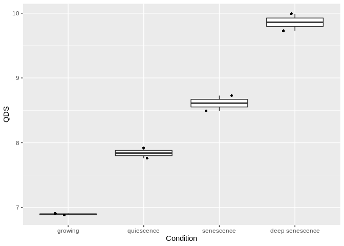

```r
make_boxplot(qds_df, ann_df= gqs_ann, x="Condition",
    levels=c("growing", "quiescence", "senescence", "deep senescence"))
```

Note how the predicted values for senescence and deep senescence (permanent non-proliferation) are higher than those for quiescence (temporary non-proliferation).

# Example 2: scRNA-seq

## Data preprocessing

Load, filter, and normalize the training data raw counts. Again, we use the REF dataset.

```r
train_df = ref_raw
train_df = BulkPreproc(train_df)
```

Load the test data raw counts. Here, we use scRNA-seq of mouse neural stem cells (NSC) in various stages of activation. The QDSWorkflow package includes the raw data in the variable nsc_raw

```r
test_df = nsc_raw
dim(test_df)
```

```
#> [1] 27998  2785
```

```r
test_df[1:10,1:10]
```

```
#>         AAACCTGCACCAGTTA-1 AAACCTGCATGGTCAT-1 AAACGGGCACCGGAAA-1 AAACGGGCAGCAGTTT-1 AAACGGGGTAAGTTCC-1 AAACGGGGTGCAACGA-1 AAAGATGAGAAGATTC-1 AAAGATGAGTAGATGT-1 AAAGATGAGTCATCCA-1 AAAGATGCAAGTCATC-1
#> Xkr4                     0                  0                  0                  0                  0                  0                  0                  0                  0                  0
#> Gm1992                   0                  0                  0                  0                  0                  0                  0                  0                  0                  0
#> Gm37381                  0                  0                  0                  0                  0                  0                  0                  0                  0                  0
#> Rp1                      0                  0                  0                  0                  0                  0                  0                  0                  0                  0
#> Rp1.1                    0                  0                  0                  0                  0                  0                  0                  0                  0                  0
#> Sox17                    0                  0                  0                  0                  0                  0                  0                  0                  0                  0
#> Gm37323                  0                  0                  0                  0                  0                  0                  0                  0                  0                  0
#> Mrpl15                   0                  2                  0                  2                  1                  0                  0                  1                  1                  0
#> Lypla1                   0                  0                  0                  1                  0                  0                  0                  0                  0                  0
#> Gm37988                  0                  0                  0                  0                  0                  0                  0                  0                  0                  0
```

Load the test sample annotations. The QDSWorkflow package includes the annotations for this dataset in the variable nsc_ann. This table gives the type and age of each cell in the dataset.

```r
test_ann = nsc_ann
head(test_ann)
```

```
#>             sample_id celltype age
#> 1: AAACCTGCACCAGTTA-1  dormant old
#> 2: AAACCTGCATGGTCAT-1   primed old
#> 3: AAACGGGCACCGGAAA-1   primed old
#> 4: AAACGGGCAGCAGTTT-1   primed old
#> 5: AAACGGGGTAAGTTCC-1   primed old
#> 6: AAACGGGGTGCAACGA-1  dormant old
```

Doublets occur when the RNA content from multiple cells are sequenced as one. Since they contain a misleadingly high number of reads, they should not be used in downstream analyses.

```r
n_before = ncol(test_df)-1
print(paste("Number of cells before filter:", n_before))
```

```
#> [1] "Number of cells before filter: 2784"
```

```r
set.seed(100)
test_df = FilterDoublets(df = test_df, ann_df = test_ann, split.by = "age", id_col="sample_id")
```

```r
n_after = ncol(test_df)
print(paste("Number of cells after filter:", n_after))
```

```
#> [1] "Number of cells after filter: 2723"
```

We can see that some doublets were filtered from the dataset.

The raw data may include dying cells and other cells of poor quality, which should not be included in downstream analysis. They can be filtered based on QC metrics like total counts (nUMI), genes expressed (nGene), genes expressed per total counts (log10GenesPerUMI), and mitochondrial ratio (mitoRatio). Plot histograms of these metrics.

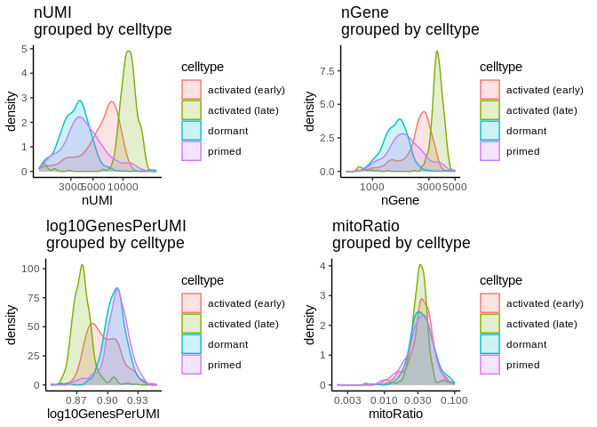

```r
plist = MakeHist(test_df, ann_df = test_ann, grouping = "celltype", mt.pattern = "^mt-")
grid.arrange(grobs = plist, ncol = 2)
```

Choose threshold values for these QC metrics. Be relatively permissive; avoid filtering out cells belonging to continuous distribution curves. From the nGene histogram, we can see that there is a small outlier peak at around 820, so we use set 820 as the nGene threshold. For the rest of the QC metrics, there are no outlier peaks, so we use the default thresholds (nUMI > 500, log10GenesPerUMI > 0.75, mitoRatio < 0.2). These thresholds will allow the majority of the cells to pass.

Run scPreproc() to (1) filter the cells by the previously chosen thresholds, (2) normalize using SCTransform, and (3) filter genes that are expressed in too few cells or have low variability. We use the default gene filter settings, which keeps the top 10000 most variable genes that are expressed in more than 0.2% of the cells.

```r
test_df = scPreproc(test_df, nGene_filt=820)
```

Take a look at the filtered, normalized test data

```r
dim(test_df)
```

```
#> [1] 10000  2711
```

```r
test_df[1:10, 1:10]
```

```
#>           Geneid AAACCTGCACCAGTTA-1 AAACGGGCACCGGAAA-1 AAACGGGCAGCAGTTT-1 AAACGGGGTAAGTTCC-1 AAACGGGGTGCAACGA-1 AAAGATGAGAAGATTC-1 AAAGATGAGTAGATGT-1 AAAGATGAGTCATCCA-1 AAAGATGCAAGTCATC-1
#> 1         Mrpl15         -0.4481624         -0.8491078          0.8353692          0.2159153        -0.34046956        -0.36801096          0.7976153          0.2522244         -0.4724528
#> 2         Lypla1         -0.3238430         -0.6360401          0.6459808         -0.5677528        -0.24557186        -0.26543806         -0.4309611         -0.5577333         -0.3417373
#> 3          Tcea1         -0.5386446         -0.3641349         -0.9881171         -0.1586864        -0.40886502        -0.44231472         -0.7064739         -0.8883321          0.8377056
#> 4          Rgs20         -0.5509796         -0.9532265          0.7197332          0.1054610        -0.44278010         1.86777087          0.6855643          0.1416752         -0.5753770
#> 5        Atp6v1h         -0.3991878         -0.7498333          1.4116762          0.5768853        -0.30930813        -0.33217483         -0.5211044         -0.6633255         -0.4196492
#> 6         Rb1cc1         -0.3807426         -0.7122785         -0.7099064         -0.6403077        -0.29681701        -0.31814023          1.3990640          0.7632542         -0.3998945
#> 7  4732440D04Rik         -0.1217007         -0.2905819         -0.2896086         -0.2611806        -0.07605117        -0.08636813         -0.2026124         -0.2568766         -0.1340891
#> 8         Pcmtd1          1.8710247          1.2769720         -0.7987830          0.4868801        -0.35140204        -0.37486888          1.1256540         -0.7133986         -0.4645511
#> 9           Rrs1         -0.5399248         -0.3369847         -0.9834969         -0.8978319        -0.41293541        -0.44563179         -0.7047679         -0.8843978         -0.5682250
#> 10        Adhfe1         -0.4647173         -0.7837101          0.4618203          2.1591388        -0.38449747         2.91654699          1.4202269         -0.7038814         -0.4830465
```

We can see that some cells and genes were filtered out.

## Bootstrap sampling

Since the test data is scRNA-seq, create bootstrap samples using the BootstrapSamples() function, which samples n cells with replacement from each group and takes the sum of their normalized counts. Bootstrapping is not required, but makes quiescence depth trends clearer. To illustrate, we will predict the quiescence depth of both single cells and bootstrapped samples.

Here, we group the cells by cell type and age, and create 100 bootstrapped samples in each group. The BootstrapSamples() function also outputs a new annotation table, which we will use downstream when visualizing the results.

```r
set.seed(100)
boot_list = BootstrapSamples(test_df, test_ann, group_col = c("celltype", "age"))
test_df_boot = boot_list$samples    #The counts for the bootstrap samples
boot_ann = boot_list$ann      #The annotations for the bootstrap samples
```

Since there are 8 total cell type/age conditions, this gives a total of 800 bootstrapped samples.

```r
dim(test_df_boot)
```

```
#> [1] 10000   800
```

```r
test_df_boot[1:10, 1:10]
```

```
#>               bootstrap_1_1 bootstrap_1_2 bootstrap_1_3 bootstrap_1_4 bootstrap_1_5 bootstrap_1_6 bootstrap_1_7 bootstrap_1_8 bootstrap_1_9 bootstrap_1_10
#> Mrpl15            2.7426131      4.532803      4.817766    10.3529916   14.02901923     0.1636645     5.2495855     -1.393085     3.0107324      12.817068
#> Lypla1           -8.7977498     -1.931112    -11.577420    -0.9008135   -1.85107241    -5.5163253     4.5996634      8.938329    -6.0365738       2.834149
#> Tcea1             0.6103776    -13.305454     -2.315950     3.6448185    5.05480019    -2.5939062     0.6945436     -2.157700    -5.6897666       3.113778
#> Rgs20           -21.1867722    -10.817677     -7.742255   -19.8976083  -15.84991821   -16.8536800   -17.3888807    -12.763167   -11.7116214     -18.493092
#> Atp6v1h          17.2495104      4.246157     -7.559852     8.1310516   -0.65929218    -6.0704097    17.9790959      4.211556     6.9824447      10.055223
#> Rb1cc1           18.3488563     -2.720145     -2.627235     2.8782139   12.37508702    15.1690820    10.1087967     -6.569445    15.1728412      17.356975
#> 4732440D04Rik     7.7038563     -3.741709      2.973157     3.5021688   -4.53523577     1.1916816     8.5847682    -11.763828    -3.0125563      -4.360175
#> Pcmtd1           -0.4961808      8.282233     -9.617638     6.7182006    0.05398934    -5.6667065    -2.2402006     -2.304049    -7.7058300       9.491000
#> Rrs1              9.9892994      4.193350     17.880557    20.3898778   17.72200249    12.1220299     8.2429110     15.206559     0.3230173       2.823583
#> Adhfe1          -12.1327939      3.859777    -19.132614   -15.8044084   -9.69552203   -17.7628809   -12.6200624    -10.245856   -16.0836304      -3.257767
```

## ID conversion

The train data contains rat Ensembl IDs, whereas the test data contains mouse gene names. Convert both to mouse Ensembl IDs.

Convert the genes in the train data from rat to mouse.

```r
train_df = convertSpecies(train_df, hm=rat_mouse_hm,
    new_id="Gene stable ID", old_id="Rat gene stable ID")
head(train_df)
```

```
#>               Geneid SRR8353399 SRR8353400 SRR8353401 SRR8353402 SRR8353403 SRR8353404 SRR8353405 SRR8353406 SRR8353407 SRR8353408 SRR8353409 SRR8353410 SRR8353411 SRR8353412 SRR8353413 SRR8353414 SRR8353415 SRR8353416 SRR8353417 SRR8353418 SRR8353419 SRR8353420 SRR8353421 SRR8353422 SRR8353423 S…
#> 1 ENSMUSG00000041037   8.932019   9.086552   9.009716   8.896902   8.885981   8.828414   8.843177   8.832417   8.883678   8.619534   8.732717   8.811044   8.542028   8.516135   8.558008   8.235690   8.235341   8.311073   8.102214   8.406979   8.257462   8.275040   8.177469   8.048595   8.252193  …
#> 2 ENSMUSG00000024871   5.603592   5.119386   5.083380   5.392930   5.172417   4.954023   5.338946   5.120549   5.106530   5.012368   5.007744   5.051836   5.078498   5.254341   4.878042   5.555643   5.149722   5.332864   5.568020   5.541862   4.712935   5.458546   4.900923   5.172501   5.550904  …
#> 3 ENSMUSG00000025190   7.910209   7.991033   7.742545   7.881535   7.840320   7.890607   8.110765   7.975279   8.045845   7.770466   7.874780   8.010278   7.885617   7.969245   7.995349   8.106177   8.324442   8.298067   8.317949   8.193550   8.245736   8.069100   8.127773   8.048595   8.022752  …
#> 4 ENSMUSG00000021569   5.742395   5.809179   5.439874   5.703251   5.651326   5.626519   5.757726   5.458921   5.679125   5.393810   5.216228   4.978940   5.078498   4.909089   4.878042   5.044553   4.640388   4.761487   5.157758   5.123080   4.905604   5.211804   5.121498   5.172501   5.528943  …
#> 5 ENSMUSG00000055407   8.447658   8.477146   8.354495   8.695779   8.635561   8.765647   8.721523   8.876380   8.726659   8.765494   8.989580   9.058340   8.960279   9.047772   8.826796   8.955801   9.049894   9.367641   8.968164   9.001206   9.056310   8.722160   8.867131   8.815149   8.586885  …
#> 6 ENSMUSG00000018820   8.108192   7.800317   7.915929   8.430847   8.212651   8.279567   8.388972   8.205319   8.182189   8.249206   8.239589   8.327575   8.331404   8.261278   8.512977   8.382689   8.628725   8.649767   8.550977   8.131675   8.493794   8.328003   8.387258   8.238130   8.080332  …
```

Then, convert the genes in the test data using a table that maps gene names to Ensembl IDs. The QDSWorkflow package includes this table in the variable nsc_genemap.

Take a look at the gene map

```r
gene_map = nsc_genemap
head(gene_map)
```

```
#>    initial_alias    converted_alias
#> 1:          Xkr4 ENSMUSG00000051951
#> 2:        Gm1992 ENSMUSG00000089699
#> 3:       Gm37381 ENSMUSG00000102343
#> 4:           Rp1 ENSMUSG00000025900
#> 5:         Rp1.1 ENSMUSG00000109048
#> 6:         Sox17 ENSMUSG00000025902
```

Convert the single cell data

```r
test_df = convertSymbol(df = test_df, gene_map = gene_map,
    conv_col = "converted_alias", init_col = "initial_alias")
test_df[1:10, 1:10]
```

```
#>                Geneid AAACCTGCACCAGTTA-1 AAACGGGCACCGGAAA-1 AAACGGGCAGCAGTTT-1 AAACGGGGTAAGTTCC-1 AAACGGGGTGCAACGA-1 AAAGATGAGAAGATTC-1 AAAGATGAGTAGATGT-1 AAAGATGAGTCATCCA-1 AAAGATGCAAGTCATC-1
#> 1  ENSMUSG00000033845         -0.4481624         -0.8491078          0.8353692          0.2159153        -0.34046956        -0.36801096          0.7976153          0.2522244         -0.4724528
#> 2  ENSMUSG00000025903         -0.3238430         -0.6360401          0.6459808         -0.5677528        -0.24557186        -0.26543806         -0.4309611         -0.5577333         -0.3417373
#> 3  ENSMUSG00000033813         -0.5386446         -0.3641349         -0.9881171         -0.1586864        -0.40886502        -0.44231472         -0.7064739         -0.8883321          0.8377056
#> 4  ENSMUSG00000002459         -0.5509796         -0.9532265          0.7197332          0.1054610        -0.44278010         1.86777087          0.6855643          0.1416752         -0.5753770
#> 5  ENSMUSG00000033793         -0.3991878         -0.7498333          1.4116762          0.5768853        -0.30930813        -0.33217483         -0.5211044         -0.6633255         -0.4196492
#> 6  ENSMUSG00000025907         -0.3807426         -0.7122785         -0.7099064         -0.6403077        -0.29681701        -0.31814023          1.3990640          0.7632542         -0.3998945
#> 7  ENSMUSG00000090031         -0.1217007         -0.2905819         -0.2896086         -0.2611806        -0.07605117        -0.08636813         -0.2026124         -0.2568766         -0.1340891
#> 8  ENSMUSG00000051285          1.8710247          1.2769720         -0.7987830          0.4868801        -0.35140204        -0.37486888          1.1256540         -0.7133986         -0.4645511
#> 9  ENSMUSG00000061024         -0.5399248         -0.3369847         -0.9834969         -0.8978319        -0.41293541        -0.44563179         -0.7047679         -0.8843978         -0.5682250
#> 10 ENSMUSG00000025911         -0.4647173         -0.7837101          0.4618203          2.1591388        -0.38449747         2.91654699          1.4202269         -0.7038814         -0.4830465
```

Convert the bootstrapped data

```r
test_df_boot = convertSymbol(df = test_df_boot, gene_map = gene_map,
    conv_col = "converted_alias", init_col = "initial_alias")
test_df_boot[1:10, 1:10]
```

```
#>                Geneid bootstrap_1_1 bootstrap_1_2 bootstrap_1_3 bootstrap_1_4 bootstrap_1_5 bootstrap_1_6 bootstrap_1_7 bootstrap_1_8 bootstrap_1_9
#> 1  ENSMUSG00000033845     2.7426131      4.532803      4.817766    10.3529916   14.02901923     0.1636645     5.2495855     -1.393085     3.0107324
#> 2  ENSMUSG00000025903    -8.7977498     -1.931112    -11.577420    -0.9008135   -1.85107241    -5.5163253     4.5996634      8.938329    -6.0365738
#> 3  ENSMUSG00000033813     0.6103776    -13.305454     -2.315950     3.6448185    5.05480019    -2.5939062     0.6945436     -2.157700    -5.6897666
#> 4  ENSMUSG00000002459   -21.1867722    -10.817677     -7.742255   -19.8976083  -15.84991821   -16.8536800   -17.3888807    -12.763167   -11.7116214
#> 5  ENSMUSG00000033793    17.2495104      4.246157     -7.559852     8.1310516   -0.65929218    -6.0704097    17.9790959      4.211556     6.9824447
#> 6  ENSMUSG00000025907    18.3488563     -2.720145     -2.627235     2.8782139   12.37508702    15.1690820    10.1087967     -6.569445    15.1728412
#> 7  ENSMUSG00000090031     7.7038563     -3.741709      2.973157     3.5021688   -4.53523577     1.1916816     8.5847682    -11.763828    -3.0125563
#> 8  ENSMUSG00000051285    -0.4961808      8.282233     -9.617638     6.7182006    0.05398934    -5.6667065    -2.2402006     -2.304049    -7.7058300
#> 9  ENSMUSG00000061024     9.9892994      4.193350     17.880557    20.3898778   17.72200249    12.1220299     8.2429110     15.206559     0.3230173
#> 10 ENSMUSG00000025911   -12.1327939      3.859777    -19.132614   -15.8044084   -9.69552203   -17.7628809   -12.6200624    -10.245856   -16.0836304
```

## Build model, make prediction

Like in the previous example, build a regression model using the train data and get the predicted quiescence depth values of the test data.

Predict the quiescence depth values of the single cell data

```r
qds_df = QDS(train_df=train_df, test_df=test_df, ann_df=ref_ann, y_col="Day")
head(qds_df)
```

```
#>                             sample_id      QDS
#> AAACCTGCACCAGTTA-1 AAACCTGCACCAGTTA-1 9.489720
#> AAACGGGCACCGGAAA-1 AAACGGGCACCGGAAA-1 7.856898
#> AAACGGGCAGCAGTTT-1 AAACGGGCAGCAGTTT-1 9.229720
#> AAACGGGGTAAGTTCC-1 AAACGGGGTAAGTTCC-1 9.264125
#> AAACGGGGTGCAACGA-1 AAACGGGGTGCAACGA-1 8.938619
#> AAAGATGAGAAGATTC-1 AAAGATGAGAAGATTC-1 8.726842
```

Predict the quiescence depth values of the bootstrapped data

```r
qds_df_boot = QDS(train_df=train_df, test_df=test_df_boot, ann_df=ref_ann, y_col="Day")
head(qds_df_boot)
```

```
#>                   sample_id      QDS
#> bootstrap_1_1 bootstrap_1_1 7.785989
#> bootstrap_1_2 bootstrap_1_2 7.954602
#> bootstrap_1_3 bootstrap_1_3 7.591598
#> bootstrap_1_4 bootstrap_1_4 7.598237
#> bootstrap_1_5 bootstrap_1_5 7.675081
#> bootstrap_1_6 bootstrap_1_6 7.621860
```

## Visualize predicted values

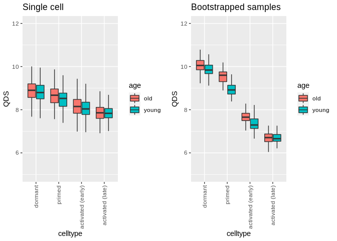

```r
#Single cell predictions
p1 = make_grouped_boxplot(qds_df, ann_df = test_ann, x1 = "celltype", x2="age",
            title="Single cell",
            levels=c("dormant", "primed", "activated (early)", "activated (late)")) +
            ylim(5, 12)+
        theme(axis.text.x = element_text(angle = 90, vjust = 0.5, hjust=1))

#Bootstrap sample predictions
p2 = make_grouped_boxplot(qds_df_boot, ann_df = boot_ann, x1 = "celltype", x2="age",
            title="Bootstrapped samples",
            levels=c("dormant", "primed", "activated (early)", "activated (late)")) +
            ylim(5, 12)+
        theme(axis.text.x = element_text(angle = 90, vjust = 0.5, hjust=1))

grid.arrange(grobs=list(p1, p2), ncol=2)
```

From the boxplots, we can see that old NSCs have deeper predicted quiescence depth than young NSCs. Also, the predicted quiescence depth decreases as cells progress from dormancy to late-stage activation, which reflects the increase in proliferative signal as stem cells become activated. The single cell and bootstrapped predictions have the same trend, but the difference between groups is more apparent in the bootstrapped samples.

For the single cell predictions, plot density curves to visualize the distribution of quiescence depth more clearly.

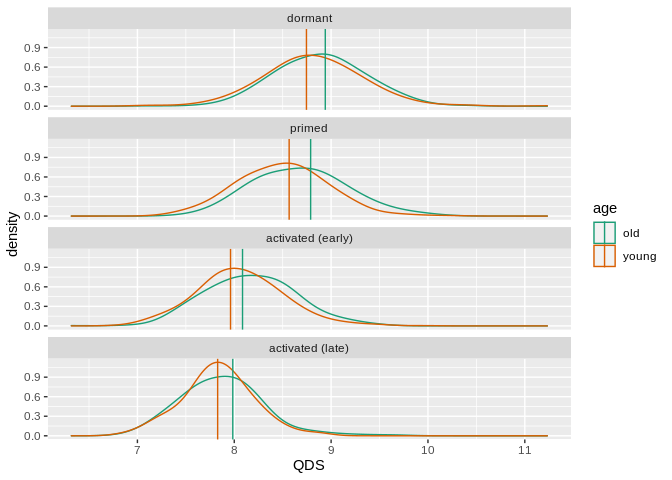

```r
make_grouped_hist(qds_df, ann_df = test_ann, grouping1 = "celltype",
                    xvar = "QDS", grouping2 = "age",
                    levels=c("dormant", "primed", "activated (early)", "activated (late)"))
```

The vertical lines show the mode of each curve. We can see that the old NSC curves have higher modes than the young NSC curves, and the modes decrease as the NSC become activated.